# Задание 4

Фокина Дарья

Данные: [https://datamarket.com/data/set/22w6/portland-oregon-average-monthly-bus-ridership-100-january-1973-through-june-1982-n114#!ds=22w6&display=line]

| Month | Portland.Oregon.average.monthly.bus.ridership...100..January.1973.through.June.1982..n.114 |
| --- | --- |
| 1960-01 | 648 |
| 1960-02 | 646 |
| 1960-03 | 639 |
| 1960-04 | 654 |
| 1960-05 | 630 |
| 1960-06 | 622 |
| 1960-07 | 617 |
| 1960-08 | 613 |
| 1960-09 | 661 |
| 1960-10 | 695 |

[output cut: 105 more lines]

```
в результате преобразования созданы NA
```

```
  [1] "1960-01-01" "1960-02-01" "1960-03-01" "1960-04-01" "1960-05-01" "1960-06-01" "1960-07-01"
  [8] "1960-08-01" "1960-09-01" "1960-10-01" "1960-11-01" "1960-12-01" "1961-01-01" "1961-02-01"
 [15] "1961-03-01" "1961-04-01" "1961-05-01" "1961-06-01" "1961-07-01" "1961-08-01" "1961-09-01"
 [22] "1961-10-01" "1961-11-01" "1961-12-01" "1962-01-01" "1962-02-01" "1962-03-01" "1962-04-01"
 [29] "1962-05-01" "1962-06-01" "1962-07-01" "1962-08-01" "1962-09-01" "1962-10-01" "1962-11-01"
 [36] "1962-12-01" "1963-01-01" "1963-02-01" "1963-03-01" "1963-04-01" "1963-05-01" "1963-06-01"
 [43] "1963-07-01" "1963-08-01" "1963-09-01" "1963-10-01" "1963-11-01" "1963-12-01" "1964-01-01"
 [50] "1964-02-01" "1964-03-01" "1964-04-01" "1964-05-01" "1964-06-01" "1964-07-01" "1964-08-01"
 [57] "1964-09-01" "1964-10-01" "1964-11-01" "1964-12-01" "1965-01-01" "1965-02-01" "1965-03-01"
 [64] "1965-04-01" "1965-05-01" "1965-06-01" "1965-07-01" "1965-08-01" "1965-09-01" "1965-10-01"
 [71] "1965-11-01" "1965-12-01" "1966-01-01" "1966-02-01" "1966-03-01" "1966-04-01" "1966-05-01"
 [78] "1966-06-01" "1966-07-01" "1966-08-01" "1966-09-01" "1966-10-01" "1966-11-01" "1966-12-01"
 [85] "1967-01-01" "1967-02-01" "1967-03-01" "1967-04-01" "1967-05-01" "1967-06-01" "1967-07-01"
 [92] "1967-08-01" "1967-09-01" "1967-10-01" "1967-11-01" "1967-12-01" "1968-01-01" "1968-02-01"
 [99] "1968-03-01" "1968-04-01" "1968-05-01" "1968-06-01" "1968-07-01" "1968-08-01" "1968-09-01"
[106] "1968-10-01" "1968-11-01" "1968-12-01" "1969-01-01" "1969-02-01" "1969-03-01" "1969-04-01"
[113] "1969-05-01" "1969-06-01" NA
  [1]  648  646  639  654  630  622  617  613  661  695  690  707  817  839  810  789  760  724
 [19]  704  691  745  803  780  761  857  907  873  910  900  880  867  854  928 1064 1103 1026
 [37] 1102 1080 1034 1083 1078 1020  984  952 1033 1114 1160 1058 1209 1200 1130 1182 1152 1116
 [55] 1098 1044 1142 1222 1234 1155 1286 1281 1224 1280 1228 1181 1156 1124 1152 1205 1260 1188
 [73] 1212 1269 1246 1299 1284 1345 1341 1308 1448 1454 1467 1431 1510 1558 1536 1523 1492 1437
 [91] 1365 1310 1441 1450 1424 1360 1429 1440 1414 1424 1408 1337 1258 1214 1326 1417 1417 1329
[109] 1461 1425 1419 1432 1394 1327   NA
```

Есть значения NA.

```
[1] 114
[1] 115
```

Значение NA всего одно - удалим его.

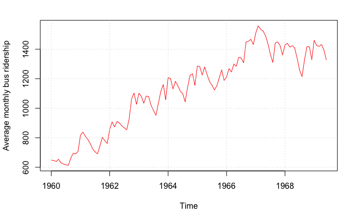

Попробуем поделить на число дней в месяце:

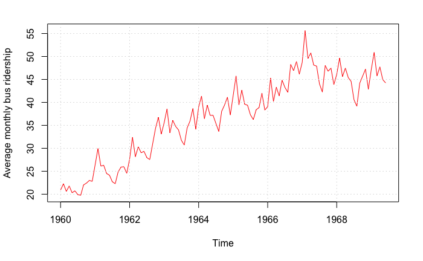

Ряд стал более регулярным

Обучающая и тестовая выборка:

```r
trainSeries <- window(tSeries, end=c(1968,06))
testSeries  <- window(tSeries, start=c(1968,07))
```

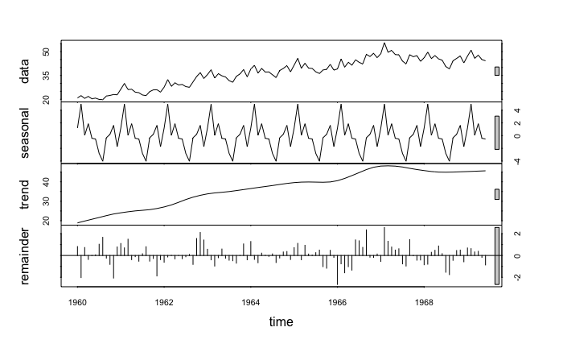

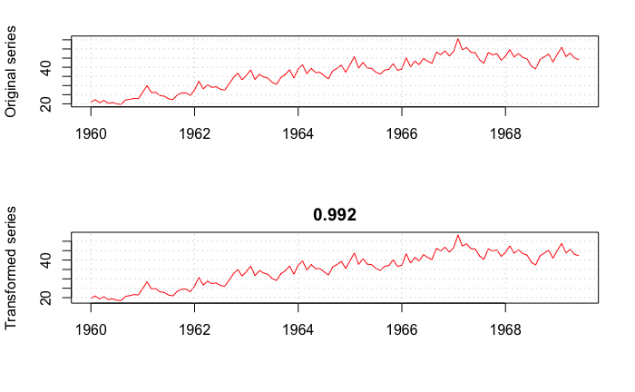

## ARIMA

### Ручной подбор модели

Ряд нестационарен (KPSS test: p<0.01)

```
p-value smaller than printed p-value
```

```
[1] 0.01
```

Сезонное дифференцирование:

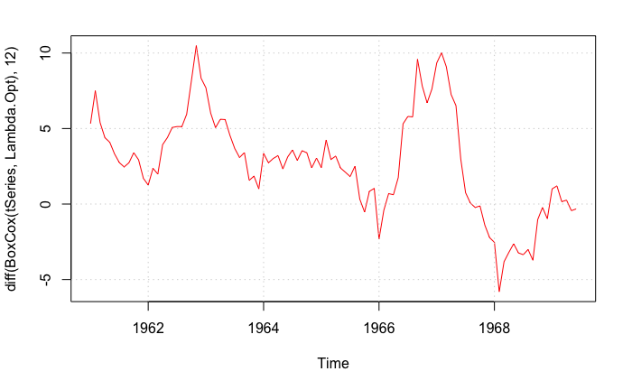

```
p-value smaller than printed p-value
```

```
[1] 0.01
```

KPSS test: p<0.01

Еще раз делаем дифференцирование:

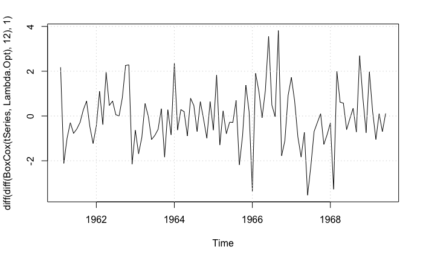

```
p-value greater than printed p-value
```

```
[1] 0.1
```

KPSS test: p > 0.1. Не отвергаем гипотезу стационарности ряда

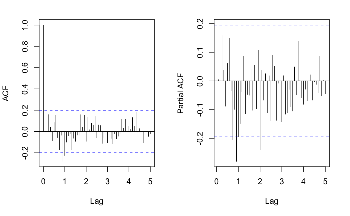

```
Series: tSeries
ARIMA(2,1,0)(0,1,1)[12]
Box Cox transformation: lambda= 0.992376

Coefficients:
          ar1      ar2     sma1
      -0.1569  -0.0294  -0.5114
s.e.   0.1091   0.1025   0.1439

sigma^2 estimated as 1.584:  log likelihood=-166.83
AIC=341.67   AICc=342.08   BIC=352.13
```

Подобранная модель - ARIMA(2,1,0)(0,1,1)$_{12}$ Остатки:

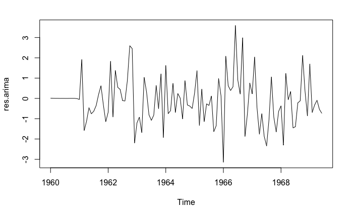

Удалим первые 14 отсчетов:

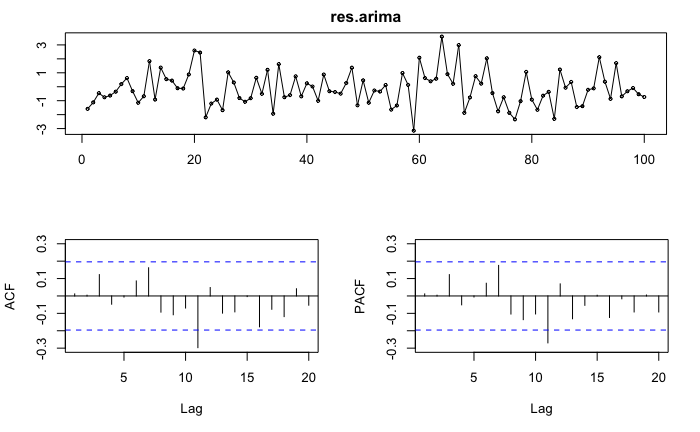

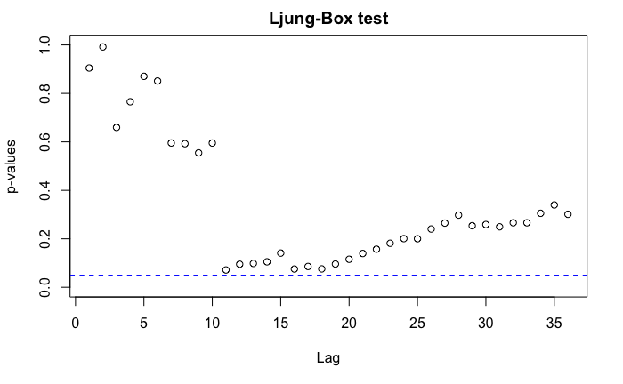

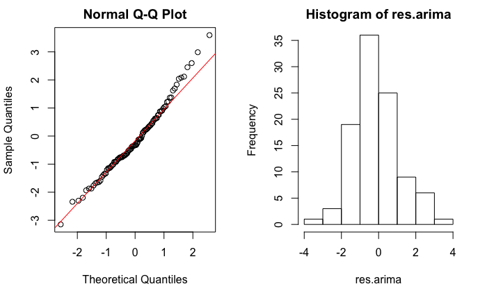

Достигаемые уровни значимости для тестов Шапиро-Уилка для проверки нормальности, Уилкоксона для проверки несмещенности, KPSS для проверки стационарности:

| Гипотеза | Критерий | Результат проверки | Достигаемый уровень значимости |
| --- | --- | --- | --- |
| Нормальность | Шапиро-Уилка | не отвергается | 0.2477193 |
| Несмещённость | Уилкоксона | не отвергается | 0.110243 |
| Стационарность | KPSS | не отвергается | 0.1 |

Значит, остатки нормальны, несмещенные, стационарны.

Настроим модель по обучающей выборке и построим ее предсказания:

```
                     ME     RMSE       MAE        MPE     MAPE      MASE         ACF1 Theil's U
Training set -0.1096216 1.223840 0.9196143 -0.3595318 2.441523 0.2342457 -0.006806109        NA
Test set      0.1112866 1.027016 0.8837634  0.1227905 1.978225 0.2251137  0.438263468 0.3149684
```

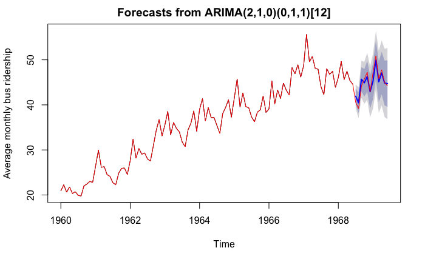

### Auto

```
Series: tSeries
ARIMA(0,1,0)(1,1,1)[12]
Box Cox transformation: lambda= 0.992376

Coefficients:
        sar1     sma1
      0.4081  -0.8258
s.e.  0.1925   0.2069

sigma^2 estimated as 1.504:  log likelihood=-165.84
AIC=337.69   AICc=337.93   BIC=345.53
```

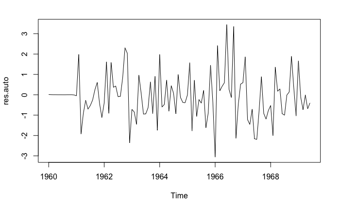

Отрежем первые 14 отсчетов:

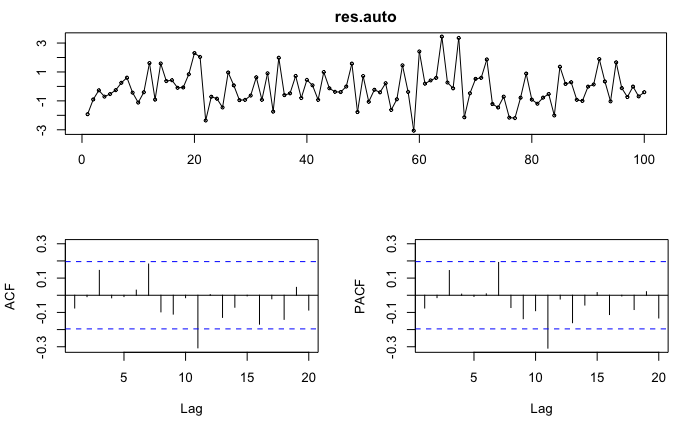

Достигаемые значения уровней значимости критерия Льюнга-Бокса:

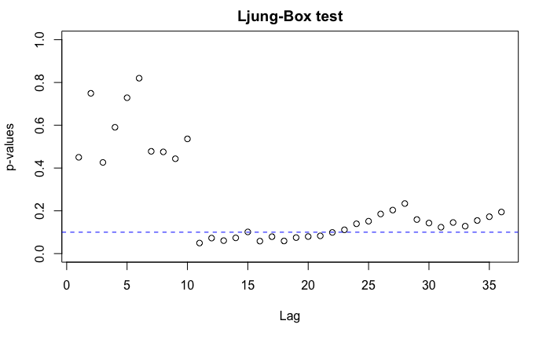

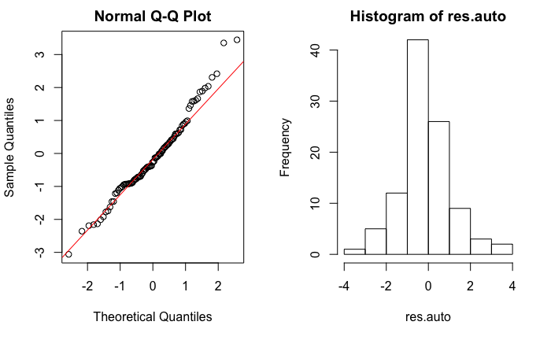

Достигаемые уровни значимости для тестов Шапиро-Уилка для проверки нормальности, Уилкоксона для проверки несмещенности, KPSS для проверки стационарности:

| Гипотеза | Критерий | Результат проверки | Достигаемый уровень значимости |
| --- | --- | --- | --- |
| Нормальность | Шапиро-Уилка | не отвергается | 0.0758325 |
| Несмещённость | Уилкоксона | не отвергается | 0.1141274 |
| Стационарность | KPSS | не отвергается | 0.1 |

Значит, остатки нормальны, несмещенные, стационарны.

Настроим модель по обучающей выборке и построим ее предсказания:

```
                     ME     RMSE       MAE        MPE     MAPE      MASE        ACF1 Theil's U
Training set -0.0974566 1.216299 0.9007226 -0.3248548 2.380763 0.2294335 -0.09037902        NA
Test set      0.8770061 1.443925 1.2727301  1.8027674 2.767147 0.3241919  0.57374729 0.4423088
```

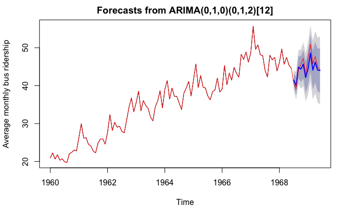

### Сравнение arima и auto-arima

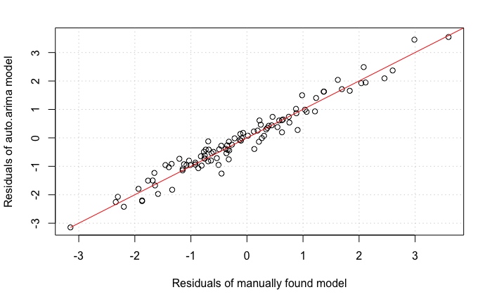

```
    Diebold-Mariano Test

data:  res.arimares.auto
DM = -0.27299, Forecast horizon = 1, Loss function power = 2, p-value = 0.7854
alternative hypothesis: two.sided
```

## ETS

```
ETS(A,A,A)

Call:
 ets(y = tSeries, lambda = Lambda.Opt)

  Box-Cox transformation: lambda= 0.9924

  Smoothing parameters:
    alpha = 0.7163
    beta  = 1e-04
    gamma = 1e-04

  Initial states:
    l = 18.3911
    b = 0.2185
    s=-1.7676 1.4881 0.1312 -0.4419 -3.9203 -2.67
           -0.4583 -0.2277 1.9158 0.1061 4.7724 1.072

  sigma:  1.0904

     AIC     AICc      BIC
593.6596 600.0346 640.1749
```

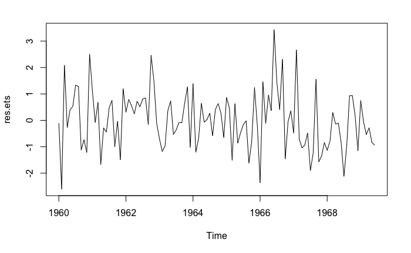

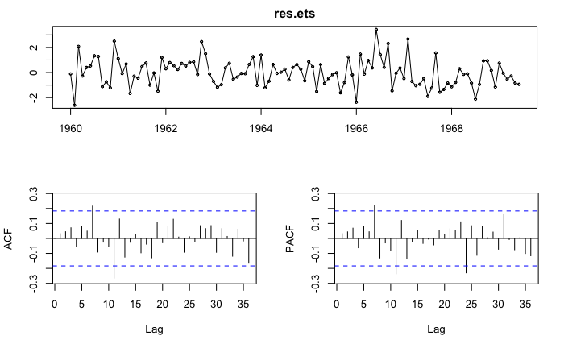

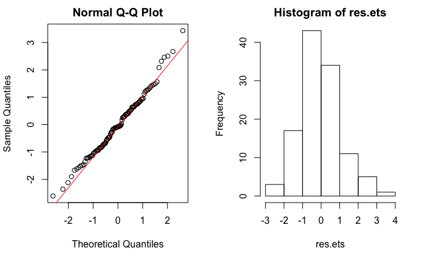

Достигаемые значения уровней значимости критерия Льюнга-Бокса:

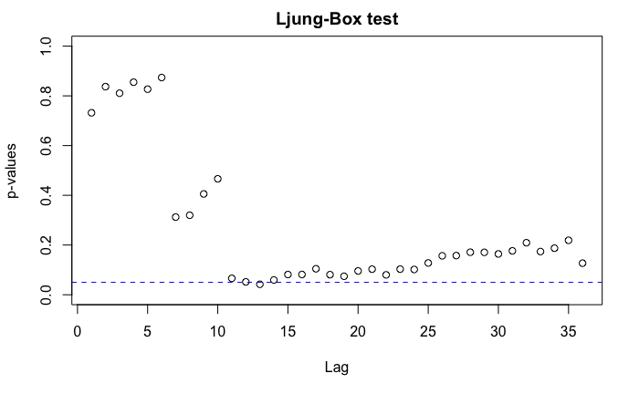

Достигаемые уровни значимости для тестов Шапиро-Уилка для проверки нормальности, Уилкоксона для проверки несмещенности, KPSS для проверки стационарности:

| Гипотеза | Критерий | Результат проверки | Достигаемый уровень значимости |
| --- | --- | --- | --- |
| Нормальность | Шапиро-Уилка | не отвергается | 0.1854586 |
| Несмещённость | Уилкоксона | не отвергается | 0.4608058 |
| Стационарность | KPSS | не отвергается | 0.1 |

Значит, остатки нормальны, несмещенные, стационарны.

Настроим модель по обучающей выборке и построим ее предсказания:

```
                      ME     RMSE       MAE        MPE     MAPE      MASE        ACF1 Theil's U
Training set  0.05913416 1.125589 0.8758307  0.1151439 2.596008 0.2230930 -0.03571195        NA
Test set     -0.53269922 1.051582 0.7702216 -1.3181757 1.818034 0.1961921  0.48487474 0.2905262
```

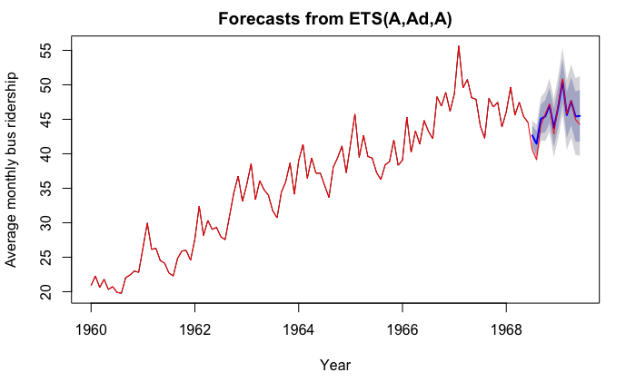

## Итоговое сравнение моделей

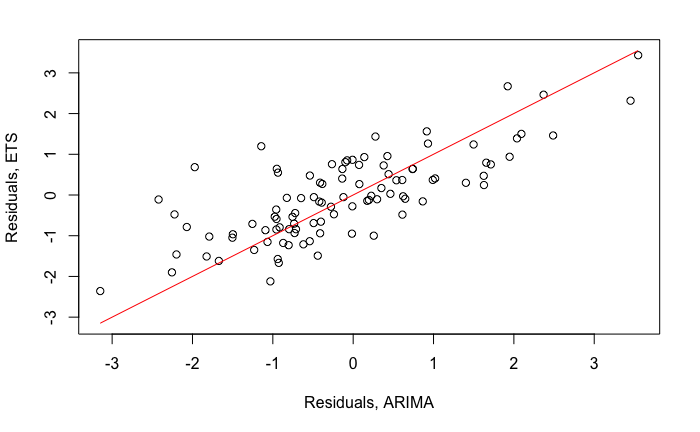

```
    Diebold-Mariano Test

data:  res.autores.ets
DM = 2.6874, Forecast horizon = 1, Loss function power = 2, p-value = 0.008449
alternative hypothesis: two.sided


    Diebold-Mariano Test

data:  res.autores.ets
DM = 2.6874, Forecast horizon = 1, Loss function power = 2, p-value = 0.004224
alternative hypothesis: greater
```

Качество модели ETS лучше. Выбираем ее.

## Итоговые предсказания

[output not shown]